# Code is Law - COMPAS Case Study Impact of design decisions on outcome

COMPAS is an algorithm used by law enforcment in different US states to predict different kinds of ''risks'' for individuals who were apprehended for crimes. One of those scores is the so-called ''Risk of Recidivism''. The predicted score is then given to judges during deliberations on granting/denying parole and deciding on imprisonment vs. parole. However, the algorithm is designed by Northpointe/Equivant and thus a corporate secret making it imperative to look at it more closely as its impact is large.  
This work is on the data science side. It shows that:

1. **Improvement** of the COMPAS accuracy (~68%) is easily **possible**
2. COMPAS is **biased by design** or maybe because of the design
3. Different **presentation** / context when the result is given **changes its meaning**
4. The **normative underpinnings are key** but are not obvious
5. Code *is* law!

## Introduction

The COMPAS dataset was acquired by ProPublica through a freedom of information request made on behalf of defendants (The total dimensionality of the data is [12366,37]). The algorithm as well as its trainign data is private property of Northpointe/Equivant and a corporate secret.

For these defendants, we have a set of variables - however, there is missing information. Moreover, we also have the ground truth on whether they recivdivated within two years. That is also the time frame for which COMPAS is claimed to be predictive.  
The main issue, however, is that the dataset by ProPublica is only available in closed source, meaning we have the raw data as well as the final variables they constructed but not their code. Consequently, we do not know how they arrived at their result for the recidivism variable and others, such as count of misdemeanours. For that reason, we use the offense data scraped by Rudin et al. (2020) and their code from their [github](https://github.com/beauCoker/age_of_unfairness), which we adapt slightly.

## Preparing the initial Data

We take the raw data from [ProPublica](https://github.com/propublica/compas-analysis/) and analyze it using the (slightly adapted) R code by Rudin et al. (2020)

Now that we merged the raw data about priors as well as the individual COMPAS assessment, we can finally make our dataset. However, here we drop many people, as they have missing information (for a detailed overview, look into the R-script ''data_to_features.R'')

```
[1] 0
```

Now we go for the actual analyis. For our analyis, we use the dataset '*_reduced_size.csv', as that has no missing values and all the information we need.

```
The autoreload extension is already loaded. To reload it, use:
  %reload_ext autoreload
```

## Dataset and Preprocessing

The preprocessing, e.g., normalization, standardization, or construction of additional variables, is done by calling on the externally defined Data_set class and its setup_data() function.

```
The maximum score (f1_score) is 0.5800327332242227
The cutoff selected is 2
use iterative marker...
done with setting up the data set...
```

## Data Introspection

Let us first have a look at how our data is structured, i.e., just the baselines before we move on.

```
Shape of X: (5759, 44)
```

| race_black | offenses_within_30 | p_felony_count_person | p_misdem_count_person | p_charge_violent | p_current_age | p_age_first_offense | p_juv_fel_count | p_felprop_violarrest | p_murder_arrest | p_felassault_arrest | p_misdemassault_arrest | p_sex_arrest | p_weapons_arrest | p_n_on_probation | p_current_on_probation | p_prob_revoke | p_arrest | p_jail30 | p_prison30 | p_prison | p_probation | is_misdem | recid_corr | recid_violent_corr | custody_days_jail | custody_days_jail_viol | jail_sentences | jail_sentences_viol | custody_days_prison | … |
| --- | --- | --- | --- | --- | --- | --- | --- | --- | --- | --- | --- | --- | --- | --- | --- | --- | --- | --- | --- | --- | --- | --- | --- | --- | --- | --- | --- | --- | --- | --- |
| 0 | 0.0 | 0.65 | 0.50 | 0.71 | 0.0 | 0.0 | 0.99 | 0.87 | 1.00 | 0.92 | 0.89 | 1.00 | 0.97 | 0.92 | 0.97 | 0.96 | 0.55 | 1.00 | 1.00 | 0.93 | 0.75 | 0.56 | 0.69 | 0.87 | 0.02 | 0.01 | 0.02 | 0.01 | 0.97 | … |
| 1 | 0.0 | 0.50 | 0.34 | 0.55 | 0.0 | 0.0 | 0.95 | 0.74 | 0.99 | 0.85 | 0.83 | 0.99 | 0.93 | 0.80 | 0.94 | 0.94 | 0.40 | 0.99 | 0.99 | 0.84 | 0.64 | 0.70 | 0.57 | 0.80 | 0.03 | 0.02 | 0.03 | 0.02 | 0.93 | … |

On the X side:

- For most variables in the dataset there is no difference between individuals
- Most variables regarding priors, we have a high percentage of zero-entries
- We have all relevant hard-facts from Boward County -> COMPAS should not have too great of a variance

For the output-side (y), we have the following columns:

```
array(['Unnamed: 0', 'Risk of Failure to Appear_decile_score',
       'Risk of Failure to Appear_raw_score',
       'Risk of Failure to Appear_score_text',
       'Risk of Recidivism_decile_score', 'Risk of Recidivism_raw_score',
       'Risk of Recidivism_score_text', 'Risk of Violence_decile_score',
       'Risk of Violence_raw_score', 'Risk of Violence_score_text',
       'recid', 'recid_violent', 'recid_proPub', 'recid_violent_proPub',
       'Risk of Recidivism_decile_score/10',
       'Risk of Violence_decile_score/10', 'target_error_regression_base',
       'target_error_regression_viol',
       'Risk of Recidivism_raw_to_decile_score',
       'Risk of Violence_raw_to_decile_score'], dtype=object)
```

For those, most are focused on some risk score. We **focus on risk of recidivism**.

Our three y-variables of interes are:

- 'recid' -> ground truth of recidivism within 2 years
- 'Risk of Recidivism_raw_score' -> most likely COMPAS model output
- 'Risk of Recidivism_decile_score'

The last score is what judges get to see. That means it is very important and may majorly influence outcome.

#### How the decile score is constructed:

The company has six norm groups differing by some age brackets, gender and hard-fat priors such as offenses and combinations of these attributes. Alternatively, the whole populace may be used as norm group. Then the decile bins are constructed in such a way that each bin holds 10% of the norm group's indivudals. We now face the following problems:

- Unkown which norm groups the officers applied to create the indivudal decile scores
- Unkown which combinations of parameters would make a valid norm group.

Only thing we know -> construct deciles such that whole dataset (representative of populace) is the norm group. So we do that!

## What the decile...

Now we plot the raw scores, i.e., the COMPAS model output over the transformed scores, i.e. the decile scores, to see how they map.

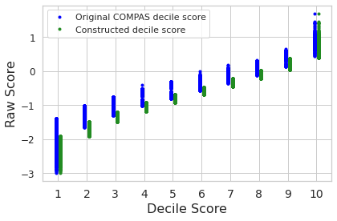

- Compared to the input, obviously, there is variance - quite a bit even
- The decile *original* scores (blue) are not only spread out, they are *overlapping*, i.e. on raw score points to different decile scores
- **Individuals with the same raw score** land in **different decile scores**
- Applying the dataset as norm group (green): Reduced but still existent overlap

Remember: *Judges see decile scores*! That means they see the *same decile* scores for individuals with *different* predicted risk of recidivism *raw scores*. It is also unclear whether they get to know the norm group at all...  
Moreover, what we see nicely here, is how the norm group shifts perceived dangerousness. That makes the decile score seem somewhat arbitrary.

Let's look at the distribution of the (original) decile scores:

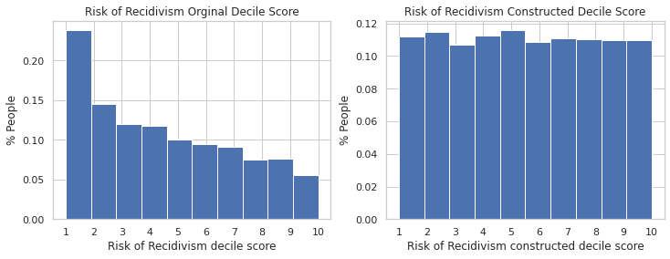

That figure gets the message across what a decile score is - in essence, the norm group always has uniform distribution!

That means:

- The decile score reflects the dangerousness compared to the norm group
- A comparison between individuals of two norm groups is simply not possible (explains overlap of boundaries in prev. figure)
- Norming against the whole dataset means a right-shift in decile scores but a reduction of overlap in raw scores and different deciles

## Young & Wild & Jailed

Now, we look at (vulnerable) subgroups. Let's start with age:

| race_black | p_current_age |
| --- | --- |
| 0 | 35.133299 |
| 1 | 29.539980 |

Do you see the correlation? Young people are also black. However, first we will stick with age. From here on, we *use the decile scores generated by norming against the whole dataset* - these are more meaningful in our context as they are more closely related to the distribution of raw scores whitin the dataset (and also because we actually know where they come from...)

```
{'<=21': 'darkred', '21<a<=30': 'darkolivegreen', '30<a<=40': 'navy', '40<a<=50': 'slategrey', '50<a<=65': 'darkorange', 'a>65': 'darkslateblue'}
The Chi-Squared p-value non_recid is 0.0
The Chi-Squared p-value non_recid black vs. white is 0.0
```

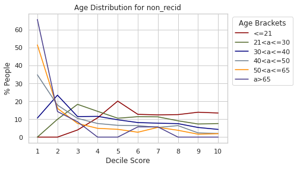

```
The Chi-Squared p-value recid is 0.0
The Chi-Squared p-value recid black vs. white is 0.0
```

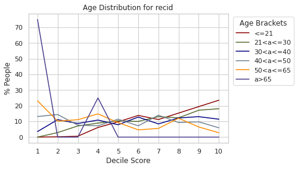

```
The Chi-Squared p-value all is 0.0
The Chi-Squared p-value all black vs. white is 0.0
```

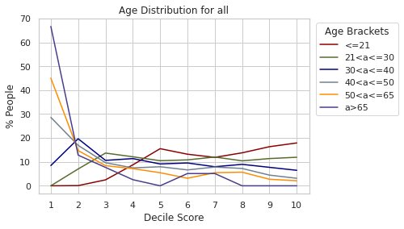

We see that there are large differences between age groups.

```
The KL-Divergence overall is 0.10820830391417197
The KL-Divergence for Non-Recidivists is 0.10079821012920274
The KL-Divergence for Recidivists is 0.08837028408852377
```

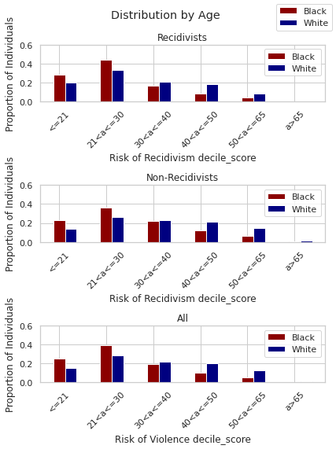

And, unsurprsingly, when plotting the precentage of people over age brackets with respect to skin color, we find that black people are younger. The KL-difference shows us this result in numbers.

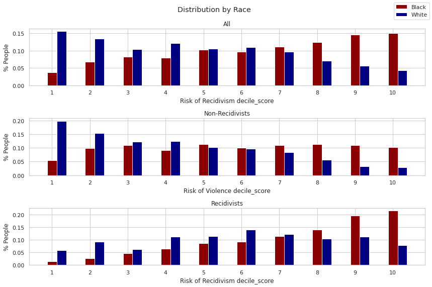

We also see

- A clear trend for black recidivists
- That the trend is not as clear for white individuals
- Basically an inverse pattern for the groups white and black
- The data holds more white non-recidivists and moe black recidivists

The question, however, is how the raw scores are distributed in the dataset as then we can see their relationship to decile scores more closely.

## Raw Insights

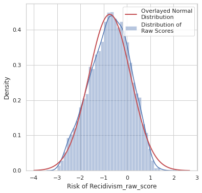

We see the actual distribution of raw scares overlayed with a normal distribution of slightly shifted mean and scale.

First, our scores seem to be approximately norammly distributed. However, while we know that the raw scores *are ordered*, we do *not know the scale*.

Assuming that our minimum is close to the global minimum and that the same holds for the maximum, we can assume that the minimum corresponds to a risk/probability of recidivism of 0% and a 100% respectively. But what about the intermediate values?

When looking at the raw score values more closely, we see that:

- They are comprised of positive and negative values
- The mean is a neighbour of 0
- We know that they are somehow related to risk/probability

In the literature, some researchers found that a lgositic regression is a good approx. of COMPAS. Moreover, a logistic function/sigmoid is also the most common one for transforming raw output to probabilities

### Reconstructing the Implicit Probabilities

First, lets look at how the sigmoid transformation would look like in terms of estimated risk/probability values:

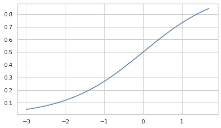

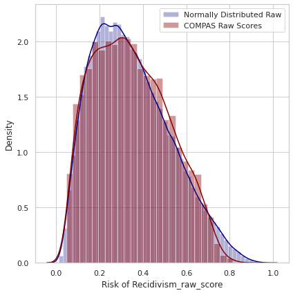

Here, we come to the normative aspect: The judges decide who to release or jail. And that brings us back to the decile scores:

1. Judges see the decile scores only
2. The decile score assigned relies on a norm group and thus on a a special partitioning of the data
3. The paritioning influences what implicit risk/probability a decile bin corresponds to

### How does different decile partitioning affect the implicit decile-risk relationship?

To see this, we apply different ways to partition the raw scores into deciles. To get the upper boundary for each decile, we look at the highgest raw score in the decile bin and calculate the implicit ris/probability.

We decide on 3 obvious ways to partition the data:

- The norm group binning
- Splitting the raw score range linearilly into 10 equally spaced bins
- Splitting the probability range into 10 equally spaced bins

| Binning Strategy | COMPAS Raw Score | COMPAS Implicit Prob. | linear cuts raw Raw Score | linear cuts raw Implicit Prob. | lin cuts prob Raw Score | lin cuts prob Implicit Prob. |
| --- | --- | --- | --- | --- | --- | --- |
| 0 | -1.92 | 0.128 | -3.63 | 0.03 | -2.12 | 0.11 |
| 1 | -1.50 | 0.182 | -2.86 | 0.05 | -1.37 | 0.20 |
| 2 | -1.20 | 0.231 | -2.09 | 0.11 | -0.86 | 0.30 |
| 3 | -0.93 | 0.283 | -1.32 | 0.21 | -0.43 | 0.39 |
| 4 | -0.69 | 0.334 | -0.54 | 0.37 | -0.05 | 0.49 |
| 5 | -0.47 | 0.385 | 0.23 | 0.56 | 0.34 | 0.58 |
| 6 | -0.23 | 0.443 | 1.00 | 0.73 | 0.75 | 0.68 |
| 7 | 0.02 | 0.505 | 1.78 | 0.86 | 1.23 | 0.77 |
| 8 | 0.37 | 0.591 | 2.55 | 0.93 | 1.90 | 0.87 |
| 9 | 1.69 | 0.844 | 3.32 | 0.97 | 3.32 | 0.97 |

As we can see, depending on the binning strategy, the judge jails completely different risk profiles for the same decile score.  
That is why making the implicit assumptions and implications hidden in the decile score is key - the normative implications are great!

Let us compare for an often proposed and used threshold of 3. *For the original COMPAS binning* strategy, every person above an *implicit risk 28.3%* would be potentially *jailed/imprisoned*.  
For the linear raw binning, we would jail already at 21%  
And finally, for the linear probability cuts, we would jail only at 40%.  
So only for the last binning strategy do the deciles directly translate to an estimated risk score.

Moreover, the original binning means that in therms of raw score, the bin width changes. The most narrow bin is only 0.22 wide.  
In comparison, the widest bin is 1.32. The impact of binning strategy on width can also be nicely illustrated with the following plots. A linear raw score binning euqals a shifting bin width in the risk (as evident from the change in gradient) and vis-a-versa.  
In comparison, the COMPAS binning already looks somewhat random.

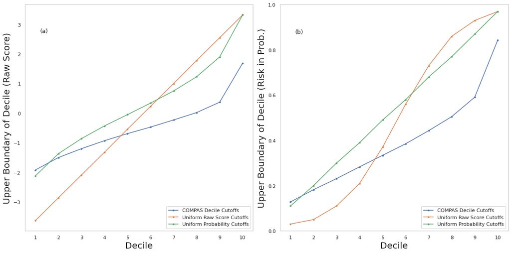

That information is also hidden from the judge.

The question now is: Why? Is there a reason or is it a random decision?

## The People vs. The Threshold

Now that we looked at how the binning affects the decile score, lets look at how choosing a certain decile threshold for which to jail affects the errors a judge/COMPAS makes. Moreover, we *also train a small neuronal net*.

The goal of the net is to recognize errors given the threshold. To that end, the net is given the Xvariables excluding race as input (as COMPAS does also not get that variable). Moreover, we also give the net the information about COMPAS predicts the individual to be a recidivists given the threshold. The model aims to optimizie accuracy and the error is the RSME. (Full specifications may be found in the paper.)

```
Do training for linear_cuts
for cutoff 0
['True Pos.' 'False Pos.' 'True Neg.' 'False Neg.']
[0.34798478 0.65152522 0.         0.        ]
use iterative marker...
['race_black', 'race_white', 'race_hispanic', 'race_asian', 'race_native']
```

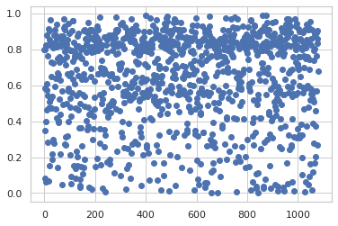

```
0.6777777777777778
Number of COMPAS correct ones 514
Total number of correct ones: 976.0
0.6833333333333333
Number of COMPAS correct ones 381
Total number of correct ones: 738.0
#####################################
for cutoff 1
['True Pos.' 'False Pos.' 'True Neg.' 'False Neg.']
[3.47621592e-01 6.43458408e-01 8.06680815e-03 3.63191853e-04]
use iterative marker...
['race_black', 'race_white', 'race_hispanic', 'race_asian', 'race_native']
```

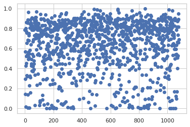

```
0.6708333333333333
Number of COMPAS correct ones 518
Total number of correct ones: 966.0
0.6898148148148148
Number of COMPAS correct ones 383
Total number of correct ones: 745.0
#####################################
for cutoff 2
['True Pos.' 'False Pos.' 'True Neg.' 'False Neg.']
[0.34274438 0.59141562 0.0601096  0.0052404 ]
use iterative marker...
['race_black', 'race_white', 'race_hispanic', 'race_asian', 'race_native']
```

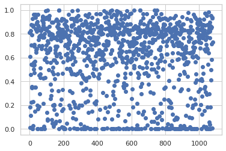

```
0.6534722222222222
Number of COMPAS correct ones 594
Total number of correct ones: 941.0
0.6833333333333333
Number of COMPAS correct ones 451
Total number of correct ones: 738.0
#####################################
for cutoff 3
['True Pos.' 'False Pos.' 'True Neg.' 'False Neg.']
[0.31187632 0.43281368 0.21871153 0.03610847]
use iterative marker...
['race_black', 'race_white', 'race_hispanic', 'race_asian', 'race_native']
```

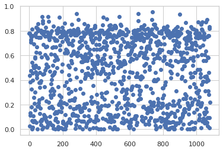

```
0.6618055555555555
Number of COMPAS correct ones 764
Total number of correct ones: 953.0
0.6842592592592592
Number of COMPAS correct ones 575
Total number of correct ones: 739.0
#####################################
for cutoff 4
['True Pos.' 'False Pos.' 'True Neg.' 'False Neg.']
[0.2179938  0.1993062  0.45221901 0.12999099]
use iterative marker...
['race_black', 'race_white', 'race_hispanic', 'race_asian', 'race_native']
```

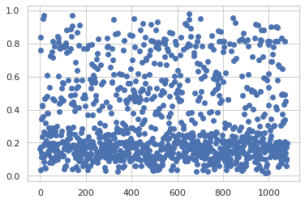

```
0.6868055555555556
Number of COMPAS correct ones 922
Total number of correct ones: 989.0
0.7101851851851851
Number of COMPAS correct ones 696
Total number of correct ones: 767.0
#####################################
for cutoff 5
['True Pos.' 'False Pos.' 'True Neg.' 'False Neg.']
[0.09337162 0.04830838 0.60321684 0.25461316]
use iterative marker...
['race_black', 'race_white', 'race_hispanic', 'race_asian', 'race_native']
```

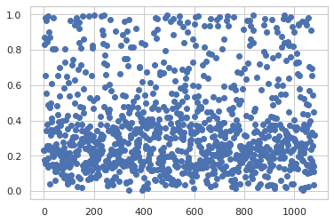

```
0.6708333333333333
Number of COMPAS correct ones 970
Total number of correct ones: 966.0
0.6805555555555556
Number of COMPAS correct ones 725
Total number of correct ones: 735.0
#####################################
for cutoff 6
['True Pos.' 'False Pos.' 'True Neg.' 'False Neg.']
[0.02151168 0.00581832 0.64570689 0.32647311]
use iterative marker...
['race_black', 'race_white', 'race_hispanic', 'race_asian', 'race_native']
```

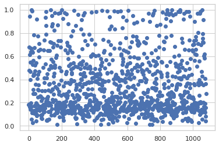

```
0.6680555555555555
Number of COMPAS correct ones 937
Total number of correct ones: 962.0
0.6861111111111111
Number of COMPAS correct ones 704
Total number of correct ones: 741.0
#####################################
for cutoff 7
['True Pos.' 'False Pos.' 'True Neg.' 'False Neg.']
[2.25520033e-03 2.94799671e-04 6.51230417e-01 3.45729583e-01]
use iterative marker...
['race_black', 'race_white', 'race_hispanic', 'race_asian', 'race_native']
```

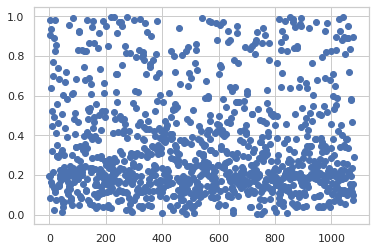

```
0.68125
Number of COMPAS correct ones 926
Total number of correct ones: 981.0
0.6953703703703704
Number of COMPAS correct ones 699
Total number of correct ones: 751.0
#####################################
for cutoff 8
['True Pos.' 'False Pos.' 'True Neg.' 'False Neg.']
[1.50418431e-04 9.58156886e-06 6.51515635e-01 3.47834365e-01]
use iterative marker...
['race_black', 'race_white', 'race_hispanic', 'race_asian', 'race_native']
```

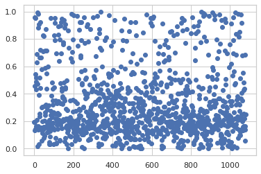

```
0.6652777777777777
Number of COMPAS correct ones 926
Total number of correct ones: 958.0
0.6833333333333333
Number of COMPAS correct ones 699
Total number of correct ones: 738.0
#####################################
for cutoff 9
['True Pos.' 'False Pos.' 'True Neg.' 'False Neg.']
[9.65108591e-06 3.48914085e-07 6.51524868e-01 3.47975132e-01]
use iterative marker...
['race_black', 'race_white', 'race_hispanic', 'race_asian', 'race_native']
```

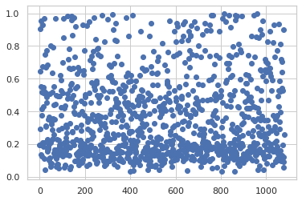

```
0.68125
Number of COMPAS correct ones 926
Total number of correct ones: 981.0
0.687962962962963
Number of COMPAS correct ones 699
Total number of correct ones: 743.0
#####################################
Do training for cutoffs_lin_prob
for cutoff 0
['True Pos.' 'False Pos.' 'True Neg.' 'False Neg.']
[0.34317602 0.59497398 0.         0.        ]
use iterative marker...
['race_black', 'race_white', 'race_hispanic', 'race_asian', 'race_native']
```

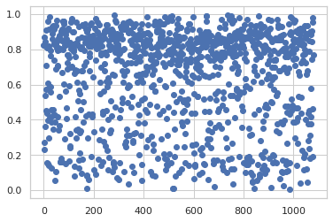

```
0.6659722222222222
Number of COMPAS correct ones 590
Total number of correct ones: 959.0
0.6916666666666667
Number of COMPAS correct ones 448
Total number of correct ones: 747.0
#####################################
for cutoff 1
['True Pos.' 'False Pos.' 'True Neg.' 'False Neg.']
[0.31555216 0.44698784 0.14798614 0.02762386]
use iterative marker...
['race_black', 'race_white', 'race_hispanic', 'race_asian', 'race_native']
```

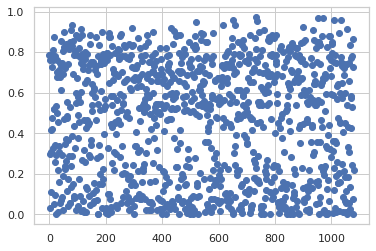